# Soc723 - SR Chapter 14

Turgut Keskintürk

2023-02-03

Hello there! Let’s start with our exercises for McElreath’s *Statistical Rethinking*, Chapter 14.

## 14E1

Adding varying slopes to the model:

$$\begin{aligned}
y_i &\sim \text{Normal}(\mu_i, \sigma) \ &\ \text{Likelihood}
\\
\mu_i &= \alpha_{GROUP[i]} + \beta_{GROUP[I]} x_i \ &\
\text{Linear Model}
\\
\left[
\begin{array}{c|c}
\alpha_{GROUP[i]}
\\
\beta_{GROUP[i]}
\end{array}
\right] &\sim \text{MVNormal}(
\left[
\begin{array}{c|c}
\alpha
\\
\beta
\end{array}
\right], S) \ &\ \text{Varying Effects}
\\
S &=
\left(
\begin{array}{c|c}
\sigma_{\alpha} \ \ \ 0
\\
0 \ \ \ \sigma_{\beta}
\end{array}
\right)
R
\left(
\begin{array}{c|c}
\sigma_{\alpha} \ \ \ 0
\\
0 \ \ \ \sigma_{\beta}
\end{array}
\right) \ &\ \text{Covariance Matrix}
\\
\\
\alpha &\sim \text{Normal}(0, 10) \ &\ \text{Good old priors}
\\
\beta &\sim \text{Normal}(0, 1)
\\
\sigma &\sim \text{Exponential}(1)
\\
\sigma_{\alpha} &\sim \text{Exponential}(1)
\\
\sigma_{\beta} &\sim \text{Exponential}(1)
\\
R &\sim \text{LKJcorr}(2) \ &\ \text{Prior for Correlation
Matrix}
\end{aligned}$$

## 14E2

The question wants us to think about a scenario where higher intercepts mean steeper slopes.

Let’s assume that we model one’s political donations as a function of campaign contact. Let’s also assume that we vary this effect across political awareness scores (low, medium, high), as well as varying the intercepts (donations) along this dimension.

It is reasonable to expect that political awareness induces higher levels of political donations.

If contacts from the campaign activate channels for more donations only among the highly aware, we have a positive correlation!

## 14E3

This might occur when there is too much shrinkage to the mean, indicating less variation among clusters. The reasons can be (a) the use of highly informative priors or (b) the fact that there is not much variation among groups in the first place.

## 14M1

Alright, gonna use McElreath’s ugly code for a function, as we will need it three times.

```r
ugly_initialize <- function(rho_value) {
  a <- 3.5
  b <- (-1)
  sigma_a <- 1
  sigma_b <- 0.5
  rho <- (rho_value)
  Mu <- c(a, b)
  cov_ab <- sigma_a * sigma_b * rho
  Sigma <-
    matrix(c(sigma_a ^ 2, cov_ab, cov_ab, sigma_b ^ 2), ncol = 2)
  sigmas <- c(sigma_a, sigma_b)
  Rho <- matrix(c(1, rho, rho, 1), nrow = 2)
  Sigma <- diag(sigmas) %*% Rho %*% diag(sigmas)
  N_cafes <- 20
  set.seed(5)
  vary_effects <- mvrnorm(N_cafes, Mu, Sigma)
  a_cafe <- vary_effects[, 1]
  b_cafe <- vary_effects[, 2]
  N_visits <- 10
  afternoon <- rep(0:1, N_visits * N_cafes / 2)
  cafe_id <- rep(1:N_cafes, each = N_visits)
  mu <- a_cafe[cafe_id] + b_cafe[cafe_id] * afternoon
  sigma <- 0.5
  wait <- rnorm(N_visits * N_cafes, mu, sigma)
  d <- data.frame(cafe = cafe_id,
                  afternoon = afternoon,
                  wait = wait)
  return(d)
}
```

Let’s fit the model from the book, with `rho` equals to -0.7.

```r
d <- ugly_initialize(-0.7)

# the model
m1 <- ulam(
  alist(
    wait ~ normal(mu, sigma),
    mu <- a_cafe[cafe] + b_cafe[cafe] * afternoon,
    c(a_cafe, b_cafe)[cafe] ~ multi_normal(c(a, b), Rho, sigma_cafe),
    a ~ normal(5, 2),
    b ~ normal(-1, 0.5),
    sigma_cafe ~ dexp(1),
    sigma ~ dexp(1),
    Rho ~ lkj_corr(2)
  ),
  data = d, chains = 4, cores = 4, log_lik = T)
```

OK, let’s fit the same model again, this time changing the `rho` to 0.

```r
d <- ugly_initialize(0)

# the model
m2 <- ulam(
  alist(
    wait ~ normal(mu, sigma),
    mu <- a_cafe[cafe] + b_cafe[cafe] * afternoon,
    c(a_cafe, b_cafe)[cafe] ~ multi_normal(c(a, b), Rho, sigma_cafe),
    a ~ normal(5, 2),
    b ~ normal(-1, 0.5),
    sigma_cafe ~ dexp(1),
    sigma ~ dexp(1),
    Rho ~ lkj_corr(2)
  ),
  data = d, chains = 4, cores = 4, log_lik = T)
```

We now have two model fits. Let’s generate draws for the posterior distribution of the `rho` parameter and inspect the differences.

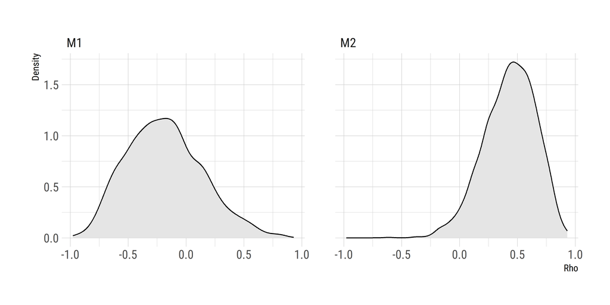

```r
bind_cols(
  tidy_draws(m1) |> janitor::clean_names() |> dplyr::select(M1 = rho_1_2),
  tidy_draws(m2) |> janitor::clean_names() |> dplyr::select(M2 = rho_1_2)
) |>
  pivot_longer(cols = everything(), names_to = "Models", values_to = "Rho") |>
  ggplot(aes(x = Rho)) +
  geom_density(fill = "gray90") +
  facet_wrap(~ Models) +
  labs("The Change in rho Parameter", x = "Rho", y = "Density")
```

Neat!

## 14M2

The same simulation (where I assume I am going to use `rho` = -0.7), with a different model. Let’s go for it!

```r
d <- ugly_initialize(-0.7)

# the model
m3 <- ulam(
  alist(
    wait ~ normal(mu, sigma),
    mu <- a_cafe[cafe] + b_cafe[cafe] * afternoon,
    a_cafe[cafe] ~ dnorm(a, sigma_alpha),
    b_cafe[cafe] ~ dnorm(b, sigma_beta),
    a ~ normal(0, 10),
    b ~ normal(0, 10),
    sigma ~ dexp(1),
    sigma_alpha ~ dexp(1),
    sigma_beta ~ dexp(1)
  ),
  data = d, chains = 4, cores = 4, log_lik = T)
```

Alright, we have our model. Let’s compare these two models:

```r
rethinking::compare(m1, m3) |>
  # prettify the results
  as_tibble() |>
  mutate(models = c(
    "New Model", "Original Model")) |>
  relocate(models) |>
  kable(digits = 2, align = "c")
```

| models | WAIC | SE | dWAIC | dSE | pWAIC | weight |
| --- | --- | --- | --- | --- | --- | --- |
| New Model | 308.33 | 20.16 | 0.00 | NA | 26.29 | 0.67 |
| Original Model | 309.78 | 20.15 | 1.44 | 0.86 | 26.90 | 0.33 |

No difference at all, though we did not explicitly model the relationship between intercepts and slopes this time. I believe this relation is not particularly informative in this model, though I believe more information is better in these circumstances!

Thank you!